# Practical 5: Text Clustering

Ayoub Bagheri

Introduction to Text Mining with R

# Introduction

In this practical, we will apply a clustering method on news articles to cluster them into different groups. Here we are going to use the following packages:

```r
library(tm)
library(tidytext)
library(dplyr)
library(proxy)
library(ggplot2)
library(tidyr)
library(dbscan)
```

# Read data

1. **The dataset that we are going to use is the BBC dataset from practical 3. This dataset consists of 2225 documents and 5 categories: business, entertainment, politics, sport, and tech. For text clustering and topic modeling, we will ignore the labels but we will use them while evaluating models. Load the Rda file of the news dataset.**

```r
load("data/news_dataset.rda")
head(df_final)
```

|  | File_Name | Content | Category | Complete_Filename |
| --- | --- | --- | --- | --- |
| 1 | 001.txt | Ad sales boost Time Warner profit\n\nQuarterly profits at US media giant TimeWarner jumped 76% to $1.13bn (£600m) for the three months to December, from $639m year-earlier.\n\nThe firm, which is now … | business | 001.txt-business |
| 2 | 002.txt | Dollar gains on Greenspan speech\n\nThe dollar has hit its highest level against the euro in almost three months after the Federal Reserve head said the US trade deficit is set to stabilise.\n\nAnd Al… | business | 002.txt-business |
| 3 | 003.txt | Yukos unit buyer faces loan claim\n\nThe owners of embattled Russian oil giant Yukos are to ask the buyer of its former production unit to pay back a $900m (£479m) loan.\n\nState-owned Rosneft bought… | business | 003.txt-business |
| 4 | 004.txt | High fuel prices hit BA's profits\n\nBritish Airways has blamed high fuel prices for a 40% drop in profits.\n\nReporting its results for the three months to 31 December 2004, the airline made a pre-ta… | business | 004.txt-business |
| 5 | 005.txt | Pernod takeover talk lifts Domecq\n\nShares in UK drinks and food firm Allied Domecq have risen on speculation that it could be the target of a takeover by France's Pernod Ricard.\n\nReports in the Wa… | business | 005.txt-business |
| 6 | 006.txt | Japan narrowly escapes recession\n\nJapan's economy teetered on the brink of a technical recession in the three months to September, figures show.\n\nRevised figures indicated growth of just 0.1% - an… | business | 006.txt-business |

```r
# Note that the next chunk (when using `DocumentTermMatrix`) will not work
# returns error invalid multibyte string 1512
# Two possible solutions:
# 1) Omission of the whole observation
# df_final <- df_final[-1512,]
# 2) Omission of the string "\xa315.8m" from that specifc text
df_final[1512,][2] <- gsub("\xa315.8m", "", df_final[1512,][2])
# I prefer the second solution
```

```r
docs <- VCorpus(VectorSource(df_final$Content))

dtm <- DocumentTermMatrix(docs,
           control = list(tolower = TRUE,
                          removeNumbers = TRUE,
                          removePunctuation = TRUE,
                          stopwords = TRUE
                         ))
# We remove A LOT of features. R is natively very weak with high dimensional data
dtm_cut <- removeSparseTerms(dtm,  sparse = 0.93)
# with sparse = 0.93 the dtm will end up with 359 terms; you can adjust this number based on your available memory

# dtm <- as.matrix(dtm) # if you have a supercomputer you can continue with this object, otherwise use the dtm_cut
dtm_cut <- as.matrix(dtm_cut)
# you can also check the wordclouds for dtm_cut
#library(wordcloud)
#wordcloud(colnames(dtm), dtm[5,], max.words = 50)
```

# Clustering methods

3. **Use the dist() function from the proxy library and calculate a distance matrix for the dtm_cut object with cosine similarity method. We will use the distance matrix for specific clustering algorithms.**

```r
# Cosine distance matrix
dist_matrix <- dist(dtm_cut, method = "cosine")
# if it takes a lot of time for your computer to create the distance matrix load the available computed dist_matrix. We made this available for you. # save(dist_matrix, file = "dist_matrix.RData")
# load("dist_matrix.RData")
```

4. **Now we can run a k-means clustering algorithm, starting out with three centers. Use the dtm_cut object as the input for `kmeans`. What does the output look like? Also check the cluster centers.**

```r
set.seed(321)
text_kmeans_clust3 <- kmeans(dtm_cut, centers = 3)
str(text_kmeans_clust3)
```

```
## List of 9
##  $ cluster     : Named int [1:2225] 1 1 1 1 1 1 1 1 1 1 ...
##   ..- attr(*, "names")= chr [1:2225] "1" "2" "3" "4" ...
##  $ centers     : num [1:3, 1:359] 0.127 0.193 0 0.287 0.208 ...
##   ..- attr(*, "dimnames")=List of 2
##   .. ..$ : chr [1:3] "1" "2" "3"
##   .. ..$ : chr [1:359] "â£bn" "â£m" "able" "according" ...
##  $ totss       : num 353497
##  $ withinss    : num [1:3] 162523 142640 17042
##  $ tot.withinss: num 322205
##  $ betweenss   : num 31292
##  $ size        : int [1:3] 1620 600 5
##  $ iter        : int 3
##  $ ifault      : int 0
##  - attr(*, "class")= chr "kmeans"
```

```r
# print the results
# text_kmeans_clust3

# show the centers
broom::tidy(text_kmeans_clust3)
```

| â£bn | â£m | able | according | across | action | added | ago | ahead | allow | almost | already | also | although | always | american | among | analysts | announced | another | around | asked | available | away | back | based | bbc | become | behind | believe | … |
| --- | --- | --- | --- | --- | --- | --- | --- | --- | --- | --- | --- | --- | --- | --- | --- | --- | --- | --- | --- | --- | --- | --- | --- | --- | --- | --- | --- | --- | --- | --- |
| 0.1271605 | 0.2870370 | 0.09320988 | 0.1358025 | 0.07901235 | 0.1296296 | 0.2796296 | 0.09259259 | 0.1117284 | 0.05185185 | 0.09074074 | 0.1524691 | 0.8141975 | 0.1086420 | 0.07654321 | 0.11543210 | 0.1018519 | 0.1197531 | 0.09259259 | 0.1493827 | 0.1345679 | 0.05802469 | 0.06790123 | 0.1148148 | 0.341358 | 0.05864198 | 0.2067901 | 0.1055556 | 0.1006173 | 0.07407407 | … |
| 0.1933333 | 0.2083333 | 0.26000000 | 0.3333333 | 0.16000000 | 0.1883333 | 0.4616667 | 0.12500000 | 0.1350000 | 0.19333333 | 0.15500000 | 0.3650000 | 1.3750000 | 0.1933333 | 0.17500000 | 0.06333333 | 0.1416667 | 0.1483333 | 0.16666667 | 0.2100000 | 0.3000000 | 0.18500000 | 0.16333333 | 0.1983333 | 0.340000 | 0.15000000 | 0.6266667 | 0.1900000 | 0.1116667 | 0.23000000 | … |
| 0.0000000 | 0.0000000 | 0.80000000 | 0.4000000 | 0.60000000 | 0.2000000 | 0.2000000 | 1.80000000 | 0.0000000 | 1.40000000 | 1.00000000 | 1.2000000 | 2.4000000 | 1.4000000 | 3.00000000 | 0.00000000 | 0.4000000 | 0.0000000 | 0.40000000 | 2.4000000 | 0.6000000 | 0.00000000 | 0.20000000 | 1.4000000 | 1.400000 | 1.00000000 | 1.2000000 | 3.8000000 | 0.2000000 | 2.60000000 | … |

The output of kmeans is a list with several bits of information. The most important being:

- cluster: A vector of integers (from 1:k) indicating the cluster to which each point is allocated.
- centers: A matrix of cluster centers.
- totss: The total sum of squares.
- withinss: Vector of within-cluster sum of squares, one component per cluster.
- tot.withinss: Total within-cluster sum of squares, i.e. sum(withinss).
- betweenss: The between-cluster sum of squares, i.e. $totss-tot.withinss$.
- size: The number of points in each cluster.
5. **Apply a PCA with 2 components on the distance matrix, and then plot the output of kmeans clustering on using the PCA outputs.**

Principal Component Analysis, or PCA, is a dimensionality-reduction method that is often used to reduce the dimensionality of large data sets, by transforming a large set of variables into a smaller one that still contains most of the information in the large set. Principal Component Analysis (PCA) is a useful technique for exploratory data analysis, allowing you to better visualize the variation present in a dataset with many variables.

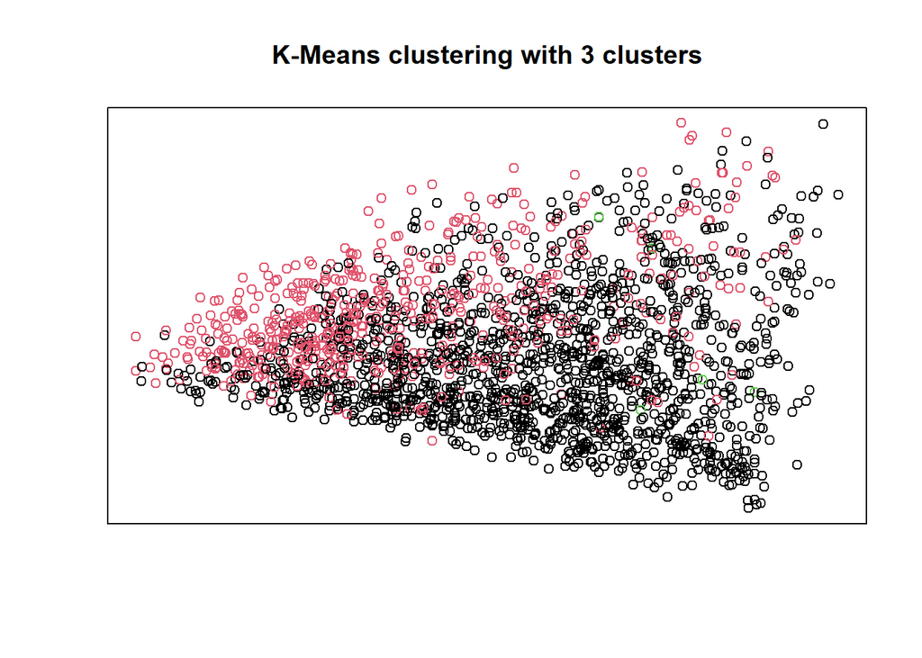

```r
set.seed(321)
# Running the PCA
points <- cmdscale(dist_matrix, k = 2)

kmeans_clusters <- text_kmeans_clust3$cluster
plot(points,
     main = 'K-Means clustering with 3 clusters',
     col = as.factor(kmeans_clusters),
     mai = c(0, 0, 0, 0),
     mar = c(0, 0, 0, 0),
     xaxt = 'n', yaxt = 'n',
     xlab = '', ylab = '')
```

6. **There are different ways of choosing k. Let’s repeat steps 3 and 4 with 4, 5 and 6 cluster centers for k-means and compare the visualizations.**

```r
set.seed(321)
text_kmeans_clust4 <- kmeans(dtm_cut, centers = 4)
tidy(text_kmeans_clust4)
```

| â£bn | â£m | able | according | across | action | added | ago | ahead | allow | almost | already | also | although | always | american | among | analysts | announced | another | around | asked | available | away | back | based | bbc | become | behind | believe | … |
| --- | --- | --- | --- | --- | --- | --- | --- | --- | --- | --- | --- | --- | --- | --- | --- | --- | --- | --- | --- | --- | --- | --- | --- | --- | --- | --- | --- | --- | --- | --- |
| 0.11745407 | 0.2959318 | 0.08661417 | 0.1384514 | 0.08005249 | 0.1233596 | 0.2683727 | 0.09711286 | 0.1102362 | 0.0511811 | 0.09251969 | 0.1515748 | 0.7906824 | 0.1036745 | 0.07349081 | 0.11154856 | 0.09645669 | 0.1115486 | 0.08923885 | 0.1489501 | 0.1286089 | 0.05380577 | 0.06627297 | 0.1108924 | 0.3307087 | 0.06167979 | 0.1909449 | 0.1017060 | 0.10039370 | 0.07020997 | … |
| 0.25413223 | 0.1797521 | 0.18595041 | 0.2148760 | 0.11776860 | 0.2045455 | 0.4669421 | 0.10537190 | 0.1425620 | 0.1797521 | 0.11776860 | 0.2665289 | 1.1797521 | 0.1508264 | 0.12396694 | 0.06198347 | 0.13636364 | 0.1487603 | 0.14462810 | 0.1384298 | 0.1880165 | 0.21487603 | 0.08264463 | 0.1756198 | 0.3347107 | 0.11363636 | 0.5619835 | 0.1466942 | 0.09297521 | 0.22520661 | … |
| 0.09433962 | 0.2452830 | 0.40094340 | 0.4952830 | 0.21226415 | 0.1698113 | 0.4481132 | 0.12264151 | 0.1179245 | 0.1650943 | 0.19811321 | 0.5000000 | 1.7358491 | 0.2877358 | 0.26886792 | 0.11792453 | 0.17452830 | 0.1933962 | 0.20754717 | 0.3490566 | 0.5235849 | 0.08962264 | 0.31603774 | 0.2405660 | 0.4292453 | 0.16981132 | 0.6981132 | 0.2783019 | 0.15094340 | 0.19811321 | … |
| 0.00000000 | 0.0000000 | 0.80000000 | 0.4000000 | 0.60000000 | 0.2000000 | 0.2000000 | 1.80000000 | 0.0000000 | 1.4000000 | 1.00000000 | 1.2000000 | 2.4000000 | 1.4000000 | 3.00000000 | 0.00000000 | 0.40000000 | 0.0000000 | 0.40000000 | 2.4000000 | 0.6000000 | 0.00000000 | 0.20000000 | 1.4000000 | 1.4000000 | 1.00000000 | 1.2000000 | 3.8000000 | 0.20000000 | 2.60000000 | … |

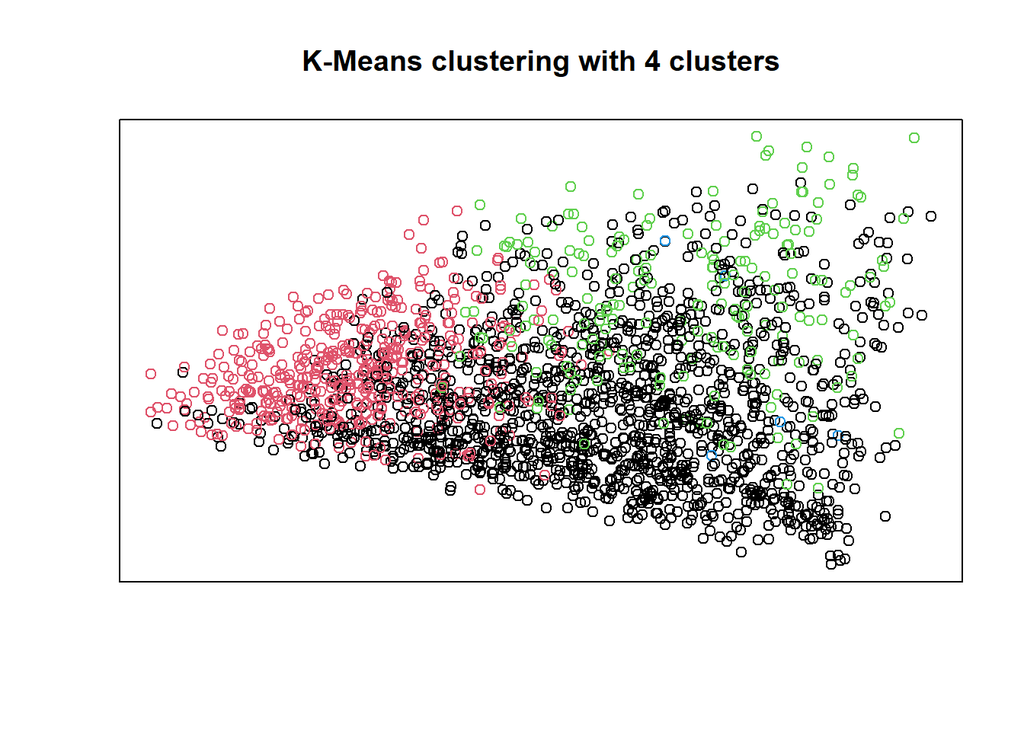

```r
kmeans_clusters <- text_kmeans_clust4$cluster
plot(points,
     main = 'K-Means clustering with 4 clusters',
     col = as.factor(kmeans_clusters),
     mai = c(0, 0, 0, 0),
     mar = c(0, 0, 0, 0),
     xaxt = 'n', yaxt = 'n',
     xlab = '', ylab = '')
```

```r
set.seed(321)
text_kmeans_clust5 <- kmeans(dtm_cut, centers = 5)
tidy(text_kmeans_clust5)
```

| â£bn | â£m | able | according | across | action | added | ago | ahead | allow | almost | already | also | although | always | american | among | analysts | announced | another | around | asked | available | away | back | based | bbc | become | behind | believe | … |
| --- | --- | --- | --- | --- | --- | --- | --- | --- | --- | --- | --- | --- | --- | --- | --- | --- | --- | --- | --- | --- | --- | --- | --- | --- | --- | --- | --- | --- | --- | --- |
| 0.11972318 | 0.29826990 | 0.0816609 | 0.1287197 | 0.07266436 | 0.1148789 | 0.2705882 | 0.09550173 | 0.1141869 | 0.04844291 | 0.09204152 | 0.1418685 | 0.7681661 | 0.1058824 | 0.07543253 | 0.11211073 | 0.08788927 | 0.1134948 | 0.08373702 | 0.1487889 | 0.1204152 | 0.05328720 | 0.06435986 | 0.1121107 | 0.3328720 | 0.05882353 | 0.1847751 | 0.0982699 | 0.10380623 | 0.07197232 | … |
| 0.27354260 | 0.22645740 | 0.1816143 | 0.1726457 | 0.10538117 | 0.2376682 | 0.4820628 | 0.10089686 | 0.1547085 | 0.17488789 | 0.07847534 | 0.2533632 | 1.1188341 | 0.1143498 | 0.09865471 | 0.06053812 | 0.13228700 | 0.1278027 | 0.15470852 | 0.1121076 | 0.1614350 | 0.21973094 | 0.08071749 | 0.1704036 | 0.3542601 | 0.10313901 | 0.5739910 | 0.1165919 | 0.07623318 | 0.23766816 | … |
| 0.04054054 | 0.02027027 | 0.3378378 | 0.7027027 | 0.21621622 | 0.1148649 | 0.3716216 | 0.13513514 | 0.0472973 | 0.15540541 | 0.30405405 | 0.5000000 | 1.7905405 | 0.2837838 | 0.32432432 | 0.10810811 | 0.18918919 | 0.2432432 | 0.10135135 | 0.2905405 | 0.5270270 | 0.10135135 | 0.24324324 | 0.1959459 | 0.2364865 | 0.22972973 | 0.5270270 | 0.2905405 | 0.18918919 | 0.07432432 | … |
| 0.11602210 | 0.30386740 | 0.3204420 | 0.2928177 | 0.22099448 | 0.1878453 | 0.3812155 | 0.12154696 | 0.1160221 | 0.16022099 | 0.14917127 | 0.4088398 | 1.4917127 | 0.2541436 | 0.15469613 | 0.11049724 | 0.19889503 | 0.1436464 | 0.24861878 | 0.3314917 | 0.4088398 | 0.08287293 | 0.23756906 | 0.2099448 | 0.4585635 | 0.11049724 | 0.6077348 | 0.2651934 | 0.09944751 | 0.20441989 | … |
| 0.00000000 | 0.00000000 | 0.8000000 | 0.4000000 | 0.60000000 | 0.2000000 | 0.2000000 | 1.80000000 | 0.0000000 | 1.40000000 | 1.00000000 | 1.2000000 | 2.4000000 | 1.4000000 | 3.00000000 | 0.00000000 | 0.40000000 | 0.0000000 | 0.40000000 | 2.4000000 | 0.6000000 | 0.00000000 | 0.20000000 | 1.4000000 | 1.4000000 | 1.00000000 | 1.2000000 | 3.8000000 | 0.20000000 | 2.60000000 | … |

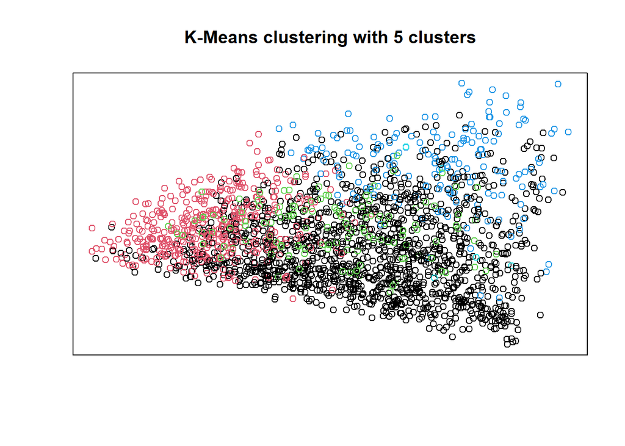

```r
kmeans_clusters <- text_kmeans_clust5$cluster
plot(points,
     main = 'K-Means clustering with 5 clusters',
     col = as.factor(kmeans_clusters),
     mai = c(0, 0, 0, 0),
     mar = c(0, 0, 0, 0),
     xaxt = 'n', yaxt = 'n',
     xlab = '', ylab = '')
```

```r
set.seed(321)
text_kmeans_clust6 <- kmeans(dtm_cut, centers = 6)
tidy(text_kmeans_clust6)
```

| â£bn | â£m | able | according | across | action | added | ago | ahead | allow | almost | already | also | although | always | american | among | analysts | announced | another | around | asked | available | away | back | based | bbc | become | behind | believe | … |
| --- | --- | --- | --- | --- | --- | --- | --- | --- | --- | --- | --- | --- | --- | --- | --- | --- | --- | --- | --- | --- | --- | --- | --- | --- | --- | --- | --- | --- | --- | --- |
| 0.12580877 | 0.29906542 | 0.08626887 | 0.13299784 | 0.07476636 | 0.12077642 | 0.2746226 | 0.09705248 | 0.11071172 | 0.04960460 | 0.09345794 | 0.1344357 | 0.736161 | 0.10567937 | 0.07548526 | 0.10567937 | 0.08123652 | 0.1193386 | 0.08195543 | 0.1480949 | 0.12077642 | 0.05535586 | 0.06757728 | 0.1107117 | 0.3429188 | 0.05607477 | 0.1703810 | 0.09777139 | 0.1020848 | 0.07476636 | … |
| 0.28009259 | 0.21759259 | 0.18287037 | 0.16898148 | 0.10416667 | 0.22916667 | 0.4861111 | 0.09953704 | 0.15740741 | 0.17824074 | 0.08101852 | 0.2523148 | 1.134259 | 0.11805556 | 0.10185185 | 0.05555556 | 0.12962963 | 0.1273148 | 0.15509259 | 0.1157407 | 0.16666667 | 0.22453704 | 0.08333333 | 0.1759259 | 0.3541667 | 0.10185185 | 0.5949074 | 0.11574074 | 0.0787037 | 0.24074074 | … |
| 0.04081633 | 0.02040816 | 0.33333333 | 0.70748299 | 0.21088435 | 0.10884354 | 0.3741497 | 0.13605442 | 0.04761905 | 0.15646259 | 0.29251701 | 0.4965986 | 1.795918 | 0.28571429 | 0.32653061 | 0.10884354 | 0.19047619 | 0.2448980 | 0.10204082 | 0.2925170 | 0.53061224 | 0.10204082 | 0.23809524 | 0.1972789 | 0.2380952 | 0.23129252 | 0.4761905 | 0.29251701 | 0.1904762 | 0.07482993 | … |
| 0.11235955 | 0.29775281 | 0.32584270 | 0.29213483 | 0.21910112 | 0.18539326 | 0.3764045 | 0.12359551 | 0.11797753 | 0.15730337 | 0.15168539 | 0.4044944 | 1.455056 | 0.25842697 | 0.15168539 | 0.10674157 | 0.20224719 | 0.1460674 | 0.25280899 | 0.3370787 | 0.41573034 | 0.07303371 | 0.24157303 | 0.2022472 | 0.4606742 | 0.11235955 | 0.5730337 | 0.25280899 | 0.1011236 | 0.19662921 | … |
| 0.00000000 | 0.00000000 | 0.80000000 | 0.40000000 | 0.60000000 | 0.20000000 | 0.2000000 | 1.80000000 | 0.00000000 | 1.40000000 | 1.00000000 | 1.2000000 | 2.400000 | 1.40000000 | 3.00000000 | 0.00000000 | 0.40000000 | 0.0000000 | 0.40000000 | 2.4000000 | 0.60000000 | 0.00000000 | 0.20000000 | 1.4000000 | 1.4000000 | 1.00000000 | 1.2000000 | 3.80000000 | 0.2000000 | 2.60000000 | … |
| 0.00000000 | 0.33333333 | 0.01388889 | 0.08333333 | 0.06944444 | 0.09722222 | 0.2222222 | 0.06944444 | 0.16666667 | 0.04166667 | 0.06944444 | 0.3472222 | 1.486111 | 0.08333333 | 0.06944444 | 0.26388889 | 0.23611111 | 0.0000000 | 0.12500000 | 0.1250000 | 0.08333333 | 0.04166667 | 0.00000000 | 0.1388889 | 0.1388889 | 0.12500000 | 0.6250000 | 0.15277778 | 0.1111111 | 0.05555556 | … |

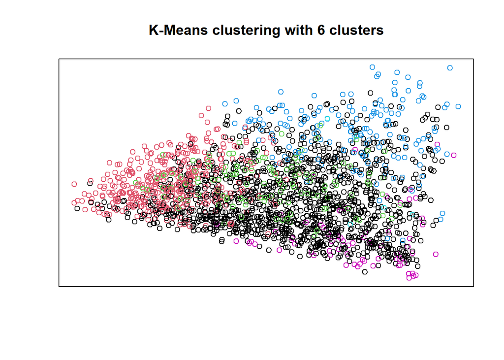

```r
kmeans_clusters <- text_kmeans_clust6$cluster
plot(points,
     main = 'K-Means clustering with 6 clusters',
     col = as.factor(kmeans_clusters),
     mai = c(0, 0, 0, 0),
     mar = c(0, 0, 0, 0),
     xaxt = 'n', yaxt = 'n',
     xlab = '', ylab = '')
```

7. **Apply the hierarchical clustering method on the distance matrix with Ward’s minimum variance method (“ward.D2”), and complete linkage method (“complete”). Plot the resulting clustering trees (dendrograms).**

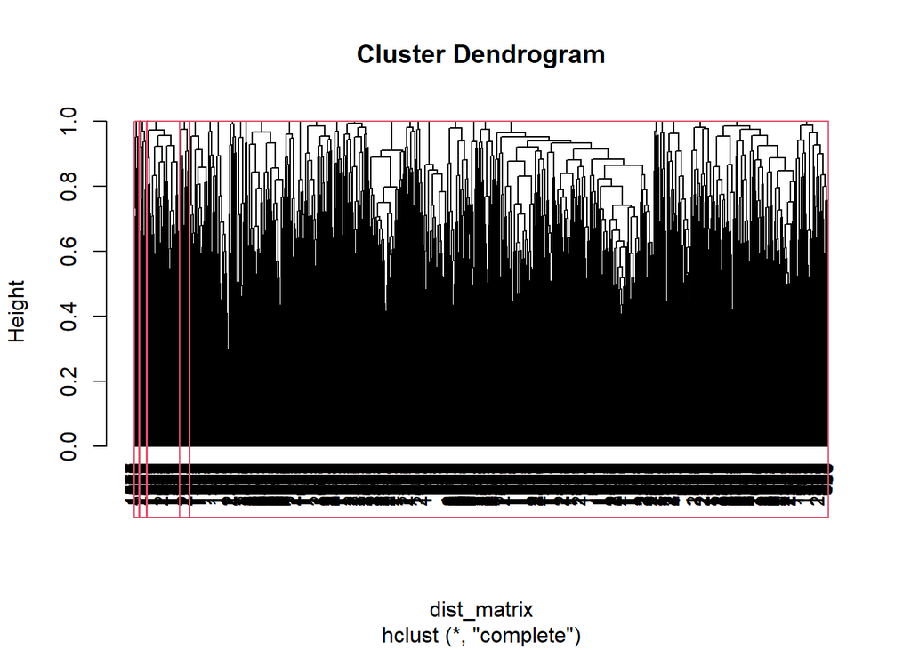

```r
set.seed(321)
hierarcom_clustering <- hclust(dist_matrix, method = "complete")
plot(hierarcom_clustering, cex = 0.9, hang = -1)
rect.hclust(hierarcom_clustering, k = 5)
```

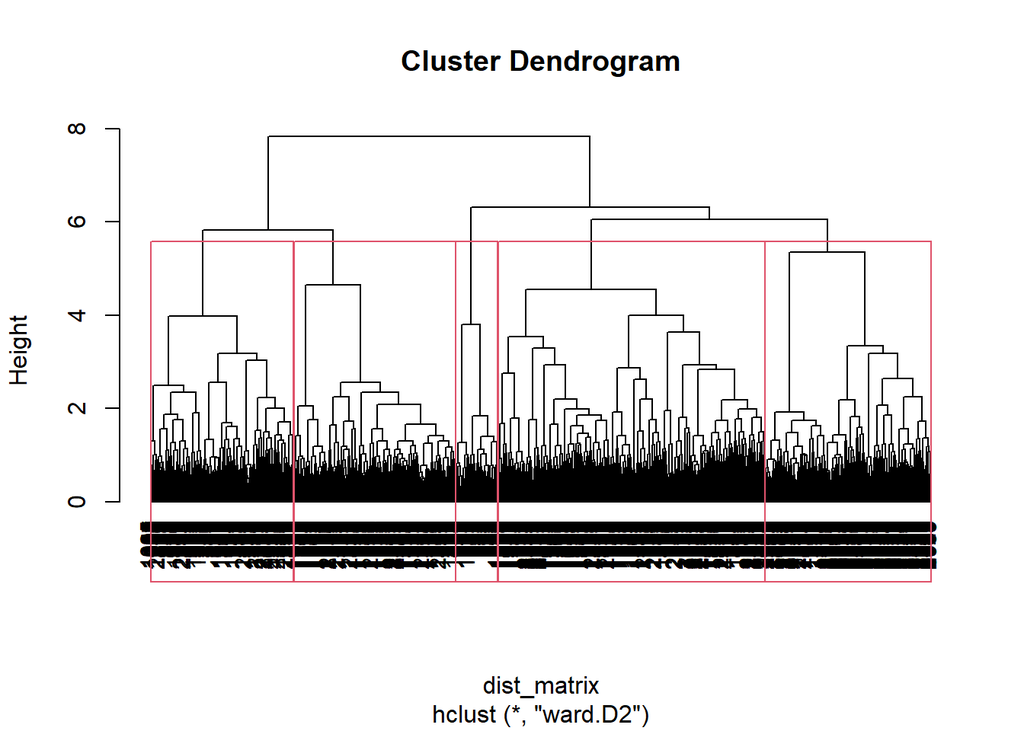

```r
set.seed(321)
hierarWard_clustering <- hclust(dist_matrix, method = "ward.D2")
plot(hierarWard_clustering, cex = 0.9, hang = -1)
rect.hclust(hierarWard_clustering, k = 5)
```

8. **Plot the output of clustering with PCA components where you cut the tree into 5 groups.**

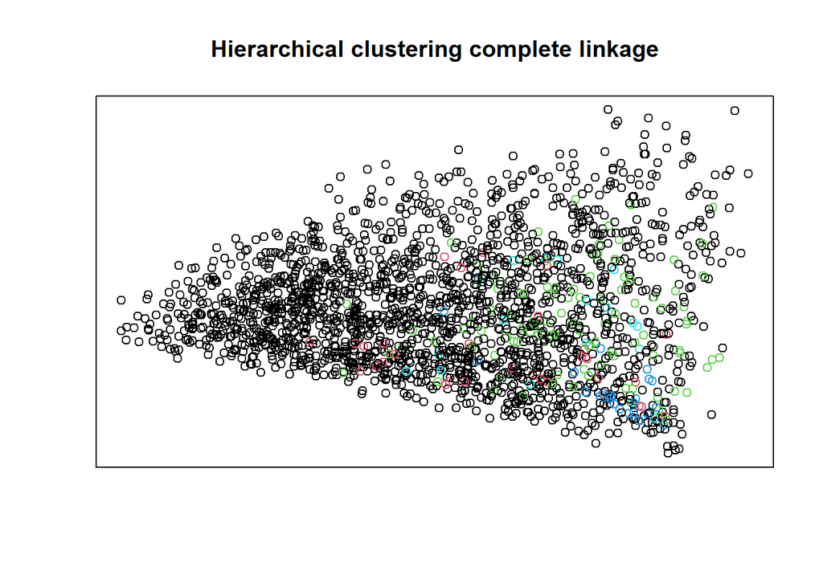

```r
set.seed(321)
hierar_clusters_com <- cutree(hierarcom_clustering, k = 5)
plot(points,
     main = 'Hierarchical clustering complete linkage',
     col = as.factor(hierar_clusters_com),
     mai = c(0, 0, 0, 0),
     mar = c(0, 0, 0, 0),
     xaxt = 'n', yaxt = 'n',
     xlab = '', ylab = '')
```

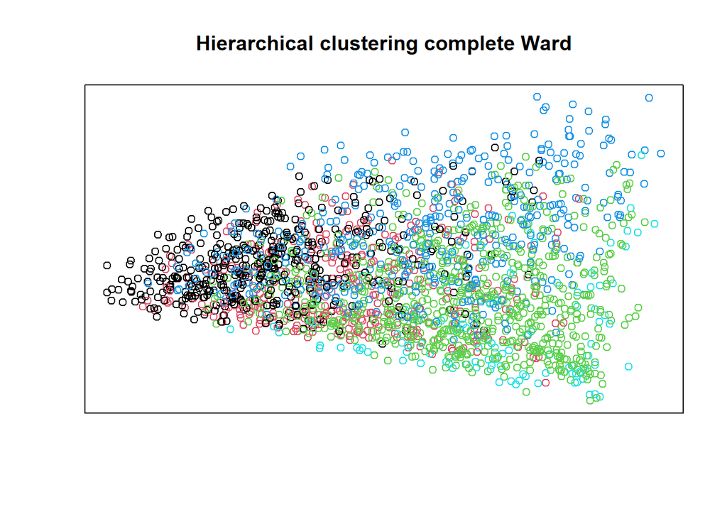

```r
set.seed(321)
hierar_clusters_ward <- cutree(hierarWard_clustering, k = 5)
plot(points,
     main = 'Hierarchical clustering complete Ward',
     col = as.factor(hierar_clusters_ward),
     mai = c(0, 0, 0, 0),
     mar = c(0, 0, 0, 0),
     xaxt = 'n', yaxt = 'n',
     xlab = '', ylab = '')
```

9. **From the library dbscan apply the dbscan algorithm on the distance matrix and plot the output with the PCA components. Compare the visualization with the output of previous methods.**

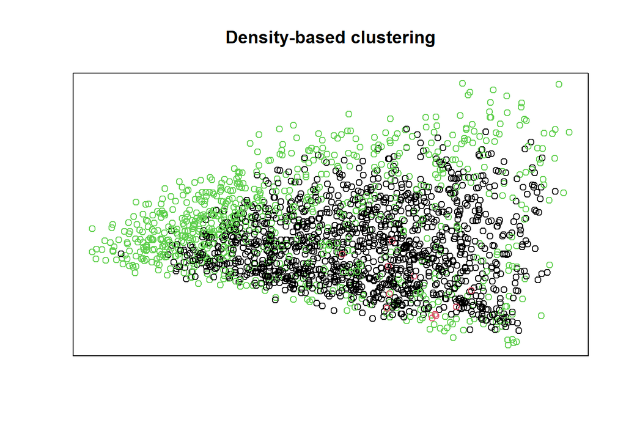

```r
set.seed(321)
dbscan_clustering <- hdbscan(dist_matrix, minPts = 10)
dbscan_clusters <- dbscan_clustering$cluster
plot(points,
     main = 'Density-based clustering',
     col = as.factor(dbscan_clusters),
     mai = c(0, 0, 0, 0),
     mar = c(0, 0, 0, 0),
     xaxt = 'n', yaxt = 'n',
     xlab = '', ylab = '')
```

# Summary

In this practical, we learned about:

- Text clustering algorithms
- Kmeans
- Hclust
- Dbscan

End of Practical